# Chi-square Test

ChatGPT 4o

2025-01-21

## 1 起源

卡方检验（Chi-square Test）是一种由卡尔·皮尔逊（Karl Pearson）在20世纪初期开发的统计方法，最初用于分析类别变量之间的关系。卡方检验主要用于测试两个分类变量之间的独立性，以及观察频数与期望频数之间的差异。由于其广泛的应用场景，卡方检验已成为统计学中不可或缺的工具之一。

## 2 原理

卡方检验的核心思想是通过比较观察到的频数（实际数据）和期望频数（假设下的理论数据），来判断两个变量是否具有统计上的显著关联。其基本原理是计算观察频数和期望频数之间的差异，通过卡方统计量来检验这些差异是否显著。

卡方统计量的计算公式为：

$$\chi^2 = \sum \frac{(O_i - E_i)^2}{E_i}$$

其中，$O_i$ 为第i个类别的观察频数，$E_i$ 为第i个类别的期望频数。

通过计算卡方统计量，并与卡方分布的临界值进行比较，可以判断是否拒绝原假设。如果卡方统计量足够大，意味着观察频数与期望频数之间的差异显著，从而可以认为两个变量之间存在关联。

## 3 适用范围

卡方检验适用于以下情况：

- **分类变量**：用于分析分类数据之间的关系，例如性别、地区、职业等。
- **独立性检验**：用于判断两个分类变量是否相互独立。
- **拟合优度检验**：用于检验实际观测值与理论分布之间的差异是否显著。

卡方检验不适用于频数过小的情况，一般要求期望频数大于5，否则结果的可靠性可能受到影响。

## 4 应用情境

卡方检验在许多实际应用中都具有广泛的应用。例如：

- **医学研究**：用于分析药物治疗效果与患者康复情况之间的关系。
- **市场调查**：用于分析消费者性别与产品偏好之间的关系。
- **社会科学研究**：用于分析社会经济地位与教育水平之间的关系。
- **质量控制**：用于比较生产过程中不同批次产品的合格率。

## 5 优缺点

### 优点

- **简单易用**：卡方检验的计算过程相对简单，适合处理大样本分类数据。
- **广泛适用**：适用于多个分类变量之间的关系分析，特别是在社会科学和市场研究中应用广泛。

### 缺点

- **对频数要求较高**：卡方检验要求期望频数不应过小，通常建议每个单元格的期望频数大于5。
- **不能量化强度**：卡方检验只能判断变量之间是否有关联，不能量化这种关联的强度。
- **敏感于样本大小**：样本大小过大会导致微小的差异也显得显著，从而产生误导性结果。

## 6 在R中的实现及结果解释

在R中，卡方检验可以通过`chisq.test()`函数实现。以下是一个实现示例：

```r
# 示例数据：消费者性别与产品偏好之间的关系
# 创建列联表
data <- matrix(c(50, 30, 15, 80, 40, 60), nrow = 2, byrow = TRUE)
colnames(data) <- c("产品A", "产品B", "产品C")
rownames(data) <- c("男性", "女性")
data
```

```
##      产品A 产品B 产品C
## 男性    50    30    15
## 女性    80    40    60
```

```r
# 进行卡方检验
chi_result <- chisq.test(data)
summary(chi_result)
```

```
##           Length Class  Mode
## statistic 1      -none- numeric
## parameter 1      -none- numeric
## p.value   1      -none- numeric
## method    1      -none- character
## data.name 1      -none- character
## observed  6      -none- numeric
## expected  6      -none- numeric
## residuals 6      -none- numeric
## stdres    6      -none- numeric
```

```r
str(chi_result)
```

```
## List of 9
##  $ statistic: Named num 10
##   ..- attr(*, "names")= chr "X-squared"
##  $ parameter: Named int 2
##   ..- attr(*, "names")= chr "df"
##  $ p.value  : num 0.00661
##  $ method   : chr "Pearson's Chi-squared test"
##  $ data.name: chr "data"
##  $ observed : num [1:2, 1:3] 50 80 30 40 15 60
##   ..- attr(*, "dimnames")=List of 2
##   .. ..$ : chr [1:2] "男性" "女性"
##   .. ..$ : chr [1:3] "产品A" "产品B" "产品C"
##  $ expected : num [1:2, 1:3] 44.9 85.1 24.2 45.8 25.9 ...
##   ..- attr(*, "dimnames")=List of 2
##   .. ..$ : chr [1:2] "男性" "女性"
##   .. ..$ : chr [1:3] "产品A" "产品B" "产品C"
##  $ residuals: num [1:2, 1:3] 0.76 -0.552 1.183 -0.86 -2.143 ...
##   ..- attr(*, "dimnames")=List of 2
##   .. ..$ : chr [1:2] "男性" "女性"
##   .. ..$ : chr [1:3] "产品A" "产品B" "产品C"
##  $ stdres   : num [1:2, 1:3] 1.29 -1.29 1.69 -1.69 -3.11 ...
##   ..- attr(*, "dimnames")=List of 2
##   .. ..$ : chr [1:2] "男性" "女性"
##   .. ..$ : chr [1:3] "产品A" "产品B" "产品C"
##  - attr(*, "class")= chr "htest"
```

```r
chi_result$method
```

```
## [1] "Pearson's Chi-squared test"
```

```r
chi_result$observed
```

```
##      产品A 产品B 产品C
## 男性    50    30    15
## 女性    80    40    60
```

```r
chi_result$expected
```

```
##         产品A    产品B    产品C
## 男性 44.90909 24.18182 25.90909
## 女性 85.09091 45.81818 49.09091
```

```r
chi_result$statistic
```

```
## X-squared
##  10.03792
```

```r
chi_result$parameter
```

```
## df
##  2
```

```r
chi_result$p.value
```

```
## [1] 0.006611415
```

```r
# 输出结果
print(chi_result)
```

```
##
##  Pearson's Chi-squared test
##
## data:  data
## X-squared = 10.038, df = 2, p-value = 0.006611
```

```r
# 计算Cramer's V
cramer_V <- sqrt(chi_result$statistic / sum(data))
cramer_V
```

```
## X-squared
## 0.1910537
```

### 结果解释

运行上述代码后，将输出卡方检验的结果，主要包括以下内容：

- **卡方统计量（$\chi^2$）**：表示观察频数和期望频数之间差异的大小。
- **自由度（df）**：表示用于计算卡方统计量的自由度。
- **p值（p-value）**：用于判断原假设是否成立。如果p值小于显著性水平（如0.05），则拒绝原假设，说明变量之间存在显著关联。
- **X-squared = 10.04**：表示卡方统计量的值。
- **df = 2**：表示自由度为2。
- **p-value = 0.007**：p值小于0.05，说明在95%的置信水平下，可以拒绝原假设，表明性别与产品偏好之间存在显著关联。

### 结果的可视化

可以使用R中的`ggplot2`包对结果进行可视化，以更直观地展示分类变量之间的关系。

```r
# 加载ggplot2包
library(ggplot2)

# 将列联表转换为数据框
data_df <- as.data.frame(as.table(data))
data_df
```

```
##   Var1  Var2 Freq
## 1 男性 产品A   50
## 2 女性 产品A   80
## 3 男性 产品B   30
## 4 女性 产品B   40
## 5 男性 产品C   15
## 6 女性 产品C   60
```

```r
data_df$Var1
```

```
## [1] 男性 女性 男性 女性 男性 女性
## Levels: 男性 女性
```

```r
data_df$Var2
```

```
## [1] 产品A 产品A 产品B 产品B 产品C 产品C
## Levels: 产品A 产品B 产品C
```

```r
data_df$Freq
```

```
## [1] 50 80 30 40 15 60
```

[figure not shown]

```r
# 绘制分组柱状图
ggplot(data_df, aes(x = Var2, y = Freq, fill = Var1)) +
  geom_bar(stat = "identity", position = "dodge") +
  labs(title = "性别与产品偏好之间的关系", x = "性别", y = "比例") +
  theme_minimal()+
  labs(fill = "产品")
```

上述代码将绘制一个分组柱状图，用于展示男性和女性对于不同产品的偏好，通过比较柱状图的高度可以更直观地看到性别与产品偏好之间的关系。

[figure not shown]

```r
ggplot(data_df, aes(x = Var2, y = Freq, fill = Var1)) +
  geom_bar(stat = "identity", position = "fill") +
  labs(title = "性别与产品偏好之间的关系", x = "产品", y = "人数") +
  theme_minimal()+
  # 修改图例标题
  labs(fill = "性别")
```

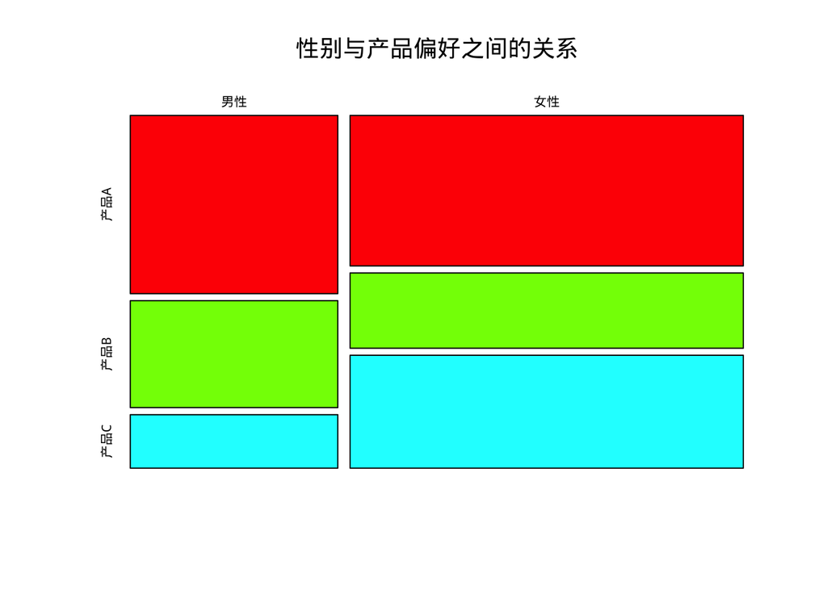

```r
# 绘制mosaic plot
mosaicplot(data, main = "性别与产品偏好之间的关系", color = rainbow(4))
```

## 7 小结

- 卡方检验用于判断分类变量之间的独立性或拟合优度。
- 适用于处理分类数据，尤其在社会科学、医学和市场调查中应用广泛。
- 计算简单易懂，但对频数有要求，且不能量化关联的强度。
- 可以通过R中的`chisq.test()`函数实现，并结合可视化更直观地展示结果。
- 结果解读需要关注卡方统计量、自由度和p值，以判断变量之间是否存在显著关联。